# Building predictive models with the mlr framework

Gleb Zakhodyakin, postlogist@gmail.com

01.10.2019

```r
library(tidyverse) # Data visualization and transformation
library(mlr) # Machine Learning framework for R
library(stringr) # string processing
library(parallelMap) # Parallel computation
library(rpart.plot) # Visualization of rpart trees
```

# Introduction

Building a model involves several steps shown below.

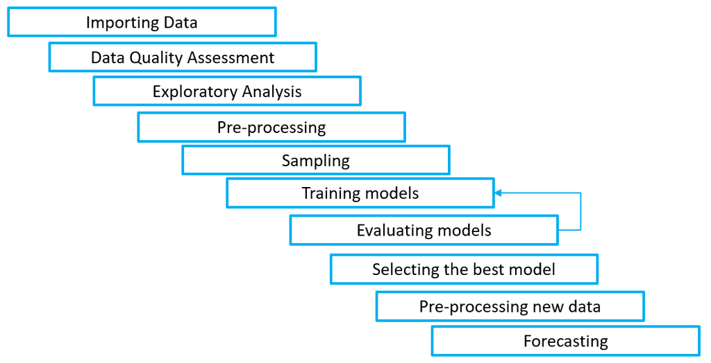

Steps for building a model

Each case of predictive modeling is unique. But all such tasks involve very similar steps. R can be employed at each of these steps. But it has a major drawback: an extreme diversity of packages, conceptual and syntactical approaches for modeling.

**Example**: consider predicting class labels using two tree-based models - rpart & ctree

```r
# rpart:
predict(m_rpart, newdata = gr, type = "class")

# ctree:
predict(m_ctree, newdata = gr, type = "response")
```

Both models use the same function for prediction, but require different arguments for doing the same task. Such differences in syntax, as well as the need to include the routine code for data preprocessing, sampling, model evaluation slow down the analysis process and increase the risk of an error. Many machine learning algorithms are computationally intensive, and the performance can be improved by using parallel computation.

Some software tools for data analysis employ a ‘Lego’ approach by providing a visual editor and a set of unified building blocks for all modeling steps.

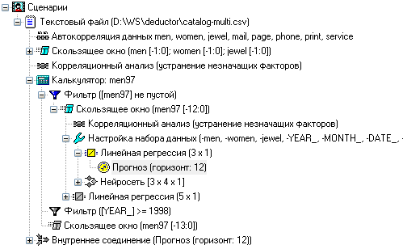

A scenario in Deductor Studio

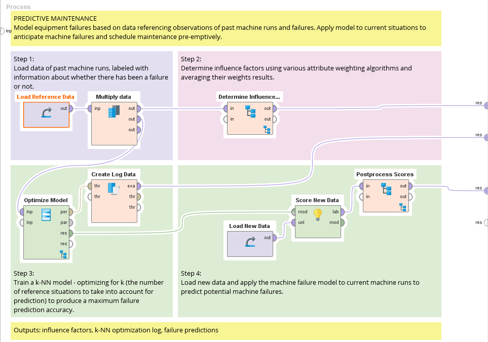

A scenario in Rapidminer

In R we use code to do the analysis. But this code can be greatly simplified by using special frameworks for building, testing, benchmarking and deploying predictive models. Such frameworks offer an unified interface for many predictive algorithms available in R.

The oldest and the most popular modeling framework in R is [caret](http://topepo.github.io/caret/index.html) package, developed by Max Kuhn.

A more modern framework is the [mlr](https://mlr.mlr-org.com/) package for Machine Learning in R, developed by Bernd Bischl. Unlike caret, the mlr package uses ggplot2 for visualization.

The schema below shows main steps and objects supporting the modeling pipeline in mlr.

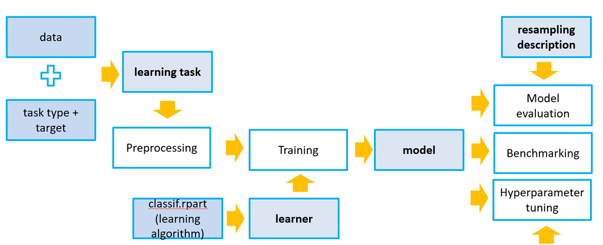

Modeling steps and supporting objects in MLR

The mlr framework unifies and automates many modeling procedures, thus saving time for the analyst.

This tutorial notebook shows examples for using mlr at different stages of modeling - data preprocessing, resampling, training and testing models, tuning the hyperparameters.

# Using mlr for regression: predicting price of an used car

## Loading and exploring the data

```r
car_ad <- read_csv("car_ad.csv")
glimpse(car_ad)
```

```
## Observations: 9,576
## Variables: 10
## $ car          <chr> "Ford", "Mercedes-Benz", "Mercedes-Benz", "Merced...
## $ price        <dbl> 15500.00, 20500.00, 35000.00, 17800.00, 33000.00,...
## $ body         <chr> "crossover", "sedan", "other", "van", "vagon", "c...
## $ mileage      <dbl> 68, 173, 135, 162, 91, 83, 199, 185, 146, 125, 0,...
## $ engV         <dbl> 2.5, 1.8, 5.5, 1.8, NA, 2.0, 2.0, 1.5, 1.8, 2.2, ...
## $ engType      <chr> "Gas", "Gas", "Petrol", "Diesel", "Other", "Petro...
## $ registration <chr> "yes", "yes", "yes", "yes", "yes", "yes", "yes", ...
## $ year         <dbl> 2010, 2011, 2008, 2012, 2013, 2013, 2003, 2011, 2...
## $ model        <chr> "Kuga", "E-Class", "CL 550", "B 180", "E-Class", ...
## $ drive        <chr> "full", "rear", "rear", "front", NA, "full", "fro...
```

Missing values:

```r
car_ad %>%
  gather(key = "variable") %>%
  filter(is.na(value) | str_length(value) == 0) %>%
  group_by(variable) %>%
  summarize(missing = n())
```

```
## # A tibble: 2 x 2
##   variable missing
##   <chr>      <int>
## 1 drive        511
## 2 engV         434
```

Two variables contain missing values - about 5% of the number of observations.

The `car` and `model` variables have a large number of categories.

The most popular cars (only cars with at least 100 sale offers):

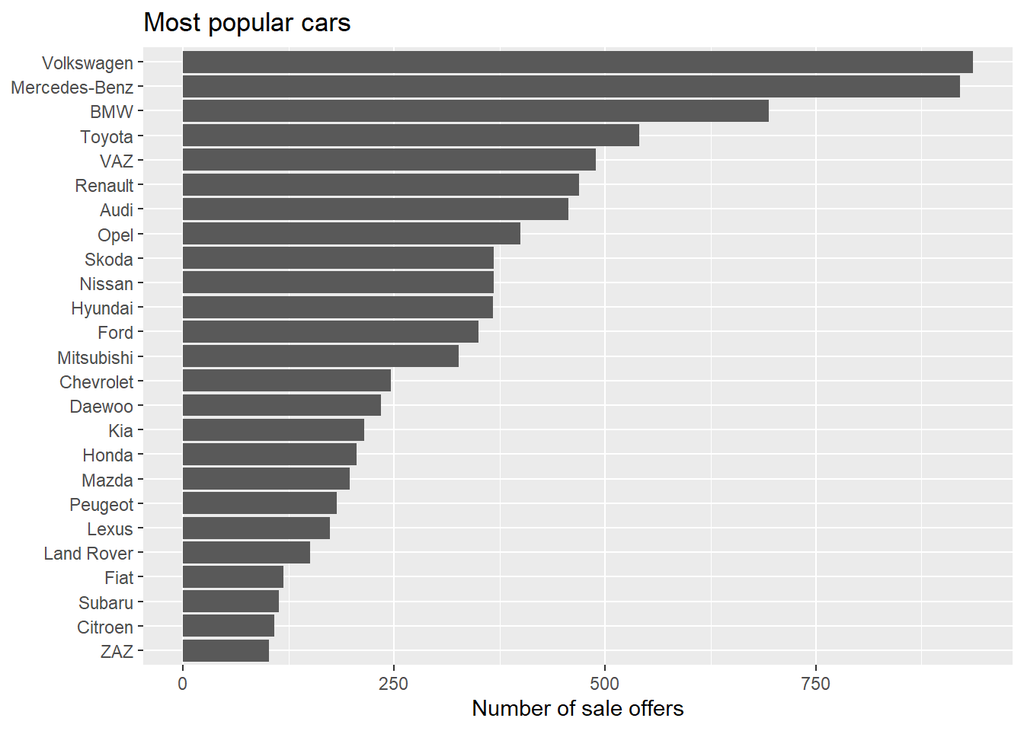

```r
car_ad %>%
  group_by(car) %>%
  summarize(count = n()) %>%
  arrange(count) %>%
  filter(count >= 100) %>%

  ggplot(aes(x = fct_inorder(car), y = count)) +
    geom_bar(stat = "identity") + coord_flip() +
  labs(x = NULL, y = "Number of sale offers",
       title = "Most popular cars")
```

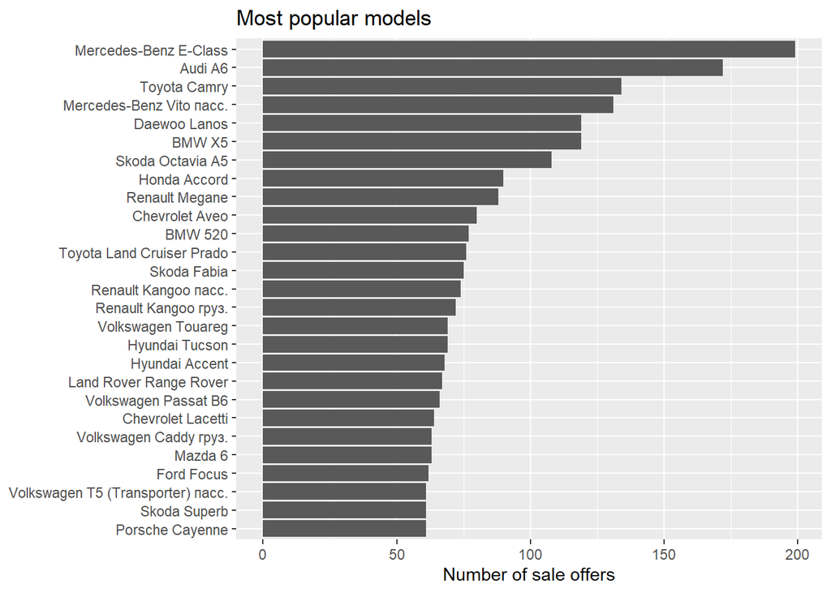

```r
car_ad1 <- car_ad %>%
  mutate(model = paste(car, model)) # Merging manufacturer and model for labels


car_ad1 %>%
  group_by(model) %>%
  summarize(count = n()) %>%
  arrange(count) %>%
  filter(count > 60) %>%

  ggplot(aes(x = fct_inorder(model), y = count)) +
    geom_bar(stat = "identity") + coord_flip() +
    labs(x = NULL, y = "Number of sale offers",
       title = "Most popular models")
```

We need to convert the text variables into factors. The factor levels will be ordered by popularity. The baseline category will be thus the most popular model.

```r
# Converting strings to factors, as required by mlr
car_ad1 <- car_ad1 %>%
  mutate_if(is_character, fct_infreq)

glimpse(car_ad1)
```

```
## Observations: 9,576
## Variables: 10
## $ car          <fct> Ford, Mercedes-Benz, Mercedes-Benz, Mercedes-Benz...
## $ price        <dbl> 15500.00, 20500.00, 35000.00, 17800.00, 33000.00,...
## $ body         <fct> crossover, sedan, other, van, vagon, crossover, s...
## $ mileage      <dbl> 68, 173, 135, 162, 91, 83, 199, 185, 146, 125, 0,...
## $ engV         <dbl> 2.5, 1.8, 5.5, 1.8, NA, 2.0, 2.0, 1.5, 1.8, 2.2, ...
## $ engType      <fct> Gas, Gas, Petrol, Diesel, Other, Petrol, Petrol, ...
## $ registration <fct> yes, yes, yes, yes, yes, yes, yes, yes, yes, yes,...
## $ year         <dbl> 2010, 2011, 2008, 2012, 2013, 2013, 2003, 2011, 2...
## $ model        <fct> Ford Kuga, Mercedes-Benz E-Class, Mercedes-Benz C...
## $ drive        <fct> full, rear, rear, front, NA, full, front, front, ...
```

The summary for all variables

```r
summary(car_ad1)
```

```
##             car           price               body         mileage
##  Volkswagen   : 936   Min.   :     0   sedan    :3646   Min.   :  0.0
##  Mercedes-Benz: 921   1st Qu.:  4999   crossover:2069   1st Qu.: 70.0
##  BMW          : 694   Median :  9200   hatch    :1252   Median :128.0
##  Toyota       : 541   Mean   : 15633   van      :1049   Mean   :138.9
##  VAZ          : 489   3rd Qu.: 16700   other    : 838   3rd Qu.:194.0
##  Renault      : 469   Max.   :547800   vagon    : 722   Max.   :999.0
##  (Other)      :5526
##       engV          engType     registration      year
##  Min.   : 0.100   Petrol:4379   yes:9015     Min.   :1953
##  1st Qu.: 1.600   Diesel:3013   no : 561     1st Qu.:2004
##  Median : 2.000   Gas   :1722                Median :2008
##  Mean   : 2.646   Other : 462                Mean   :2007
##  3rd Qu.: 2.500                              3rd Qu.:2012
##  Max.   :99.990                              Max.   :2016
##  NA's   :434
##                       model        drive
##  Mercedes-Benz E-Class   : 199   front:5188
##  Audi A6                 : 172   full :2500
##  Toyota Camry            : 134   rear :1377
##  Mercedes-Benz Vito пасс.: 131   NA's : 511
##  BMW X5                  : 119
##  Daewoo Lanos            : 119
##  (Other)                 :8702
```

The distributions for quantitative variables are skewed. The engine volume variable has strange values, like 100 liters.

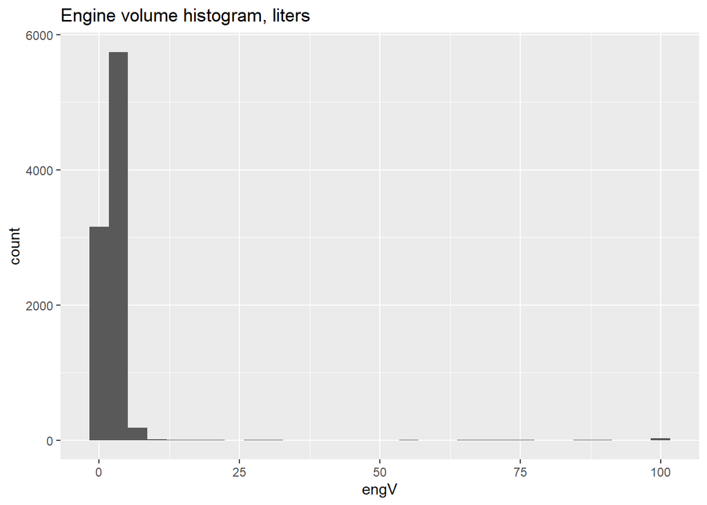

```r
ggplot(car_ad1, aes(x = engV)) +
  geom_histogram() +
  #xlim(c(0, 10)) +
  labs(title = "Engine volume histogram, liters")
```

```r
car_ad1 %>%
  filter(engV > 10) %>%
  arrange(engV) %>%
  head(10)
```

```
## # A tibble: 10 x 10
##    car    price body  mileage  engV engType registration  year model  drive
##    <fct>  <dbl> <fct>   <dbl> <dbl> <fct>   <fct>        <dbl> <fct>  <fct>
##  1 Opel    9100 sedan     147  11.5 Petrol  yes           2008 Opel ~ front
##  2 GAZ    15000 sedan       1  12   Petrol  yes           1962 GAZ 21 rear
##  3 Opel    5700 sedan     135  14   Petrol  yes           2005 Opel ~ front
##  4 Citro~  1650 van       180  14   Petrol  no            2006 Citro~ front
##  5 Renau~  4800 van       113  15   Diesel  yes           2006 Renau~ front
##  6 Opel    3000 sedan     276  17   Diesel  yes           1993 Opel ~ <NA>
##  7 Hyund~ 14850 sedan      75  18   Gas     yes           2012 Hyund~ front
##  8 Skoda   8200 sedan       1  18   Gas     yes           2005 Skoda~ <NA>
##  9 Audi    1950 sedan     320  19   Other   no            1996 Audi ~ <NA>
## 10 Renau~  2950 vagon     280  19   Diesel  yes           2000 Renau~ front
```

The `99.99` value for the `engV` probably represents a missing observation. Large volumes like 17 liters for an automobile are probably due to data entry errors or wrong units. We’ll replace with NAs all strange values. We’ll also remove all listings with a zero price. Since the price is inverse proportional to mileage, we can also create an additional variable = `1/mileage`.

```r
car_ad1 <-  car_ad1 %>%
  filter(price > 0) %>%
  mutate(inv_mileage = 1000 / (mileage + 1),
         engV = if_else(engV > 8, as.numeric(NA), engV))
```

## Regression with mlr

### Step 1. Creating a learning task

A **learning task** in mlr is a wrapper for the data table that includes additional attributes of the problem. For example, a **target** variable we are going to predict is marked, the learning task type is specified (regression or classification); a descriptive text label is associated with the task, that can be later used for reporting and visualization.

Price prediction is a regression task, and we use the `makeRegrTask()` to create it.

```r
car_task <- makeRegrTask(id = "Car prices",
                         data = car_ad1, target = "price",
                         fixup.data = "warn")
print(car_task)
```

```
## Supervised task: Car prices
## Type: regr
## Target: price
## Observations: 9309
## Features:
##    numerics     factors     ordered functionals
##           4           6           0           0
## Missings: TRUE
## Has weights: FALSE
## Has blocking: FALSE
## Has coordinates: FALSE
```

The resulting object contains both the dataset, and special attributes that are used in other modeling stages. The mlr package includes many functions for manipulating the learning tasks.

For example, we can get the number of examples in the learning task this way:

```r
getTaskSize(car_task)
```

```
## [1] 9309
```

### Step 2. Creating a learner

The mlr package allows using more than a hundred algorithms for classification and regression. The list of available algorithms is provided by the `listLearners()` function. It is also provided in the package’s help files and web site - [Available Learners]https://mlr.mlr-org.com/articles/tutorial/integrated_learners.html

```r
listLearners(obj = "regr") %>%
  select(name, class) %>%
  mutate(name = substr(name, 1, 60)) %>%
  head(10) %>% # limiting the output to just 10 learners
  arrange(name)
```

```
##                                                            name
## 1                            Bayesian Additive Regression Trees
## 2                                                 Bayesian CART
## 3                                     Bayesian Gaussian Process
## 4  Bayesian Gaussian Process with jumps to the Limiting Linear
## 5                                         Bayesian Linear Model
## 6      Bayesian regularization for feed-forward neural networks
## 7                               Bayesian Treed Gaussian Process
## 8  Bayesian Treed Gaussian Process with jumps to the Limiting L
## 9                                   Bayesian Treed Linear Model
## 10                                            Gradient Boosting
##               class
## 1  regr.bartMachine
## 2        regr.bcart
## 3          regr.bgp
## 4       regr.bgpllm
## 5          regr.blm
## 6         regr.brnn
## 7         regr.btgp
## 8      regr.btgpllm
## 9         regr.btlm
## 10         regr.bst
```

The `class` column contains a wrapper class for an algorithm, that can be specified in the `makeLearner()` function. In addition to the class, the list of learners contains attributes for each algorithm. For example, if a particular algorithm can estimate the confidence or the standard error for a prediction. These attributes can be used to select a suitable algorithm programmatically.

The overall number of regression algorithms in mlr:

```r
listLearners(obj = "regr") %>% count()
```

```
## # A tibble: 1 x 1
##       n
##   <int>
## 1    59
```

Now we create a learner based on multiple linear regression

```r
lrn_lm <- makeLearner("regr.lm", id = "Linear Regression")
lrn_lm
```

```
## Learner Linear Regression from package stats
## Type: regr
## Name: Simple Linear Regression; Short name: lm
## Class: regr.lm
## Properties: numerics,factors,se,weights
## Predict-Type: response
## Hyperparameters:
```

The resulting object has metadata on the algorithm type, attributes, default prediction type and available hyperparameters. Hyperparameters are the parameters of an algorithm, that control its behaviour. Such hyperparameters are not estimated based on the data, they must be set apriori.

For example, the OLS linear regression has no hyperparameters. The coefficients of the model are estimated from the data. But the Lasso regression has one hyperparameter - $\lambda$, that sets the weight of the penalty term and effectively limits the complexity of the resulting model.

A list and the default values can be viewed using the `getLearnerParamSet()` and `getLearnerParVals()` functions.

```r
lrn_lm %>% getLearnerParamSet()
```

```
##                Type len   Def   Constr Req Tunable Trafo
## tol         numeric   - 1e-07 0 to Inf   -    TRUE     -
## singular.ok logical   -  TRUE        -   -   FALSE     -
```

The description of the parameters is available via the `helpLearnerParam()` function.

```r
lrn_lm %>% helpLearnerParam()
```

```
## Documentation for the following parameters is present:
## - tol (stats::lm.fit)
## - singular.ok (stats::lm)
```

### Step 3. Preprocessing

Preprocessing means transforming the training data to the state that is optimal for modeling.

For example:

- removing some variables
- handling missing values
- filtering outliers
- removing variables with constant values

The non-required columns can be removed from the learning task with the `dropFeatures()` function.

On the exploratory analysis stage we found that car model and maker names are categorical variables with a large number of levels. These variables are definitively important for price prediction, but it’s not possible to include them to a model directly. Doing so will lead to a few issues: - the model will become very large (each category will be converted into a dummy variable) - when splitting the training and testing subsets, some rare categories may appear only in training sample, which will cause an error when predicting

To prevent this, we’ll merge all rare categories into a single “.other” category

```r
car_task <- car_task %>%
  mergeSmallFactorLevels(min.perc = 0.015, # minimum relative frequency of a category to appear on it's own
                         new.level = ".other")
```

You can read about the issue of new factor levels when predicting here: https://github.com/mlr-org/mlr/issues/811

We’ve already removed the outliers (incorrect values for engine size and price) using the standard tools available in `dplyr`. But mlr also has features to handle outliers - see https://mlr.mlr-org.com/articles/tutorial/preproc.html

Many algorithms can’t handle NA’s. For example, an attempt to train a linear regression on a daset with NA’s will fail.

```r
#m_lm <- train(lrn_lm, car_task) # doesn't work due to NA
```

Missing values can be filtered or replaced with a `typical` or special values. The mlr package has `impute()` function, that can be used to fill in the NAs.

Here we will replace NAs for categorical variables with the “Unknown” value. For quantitative predictors we’ll simply use the average.

```r
car_imputation <- car_task %>%
  impute(classes = list(numeric = imputeMean(),
                        factor = imputeConstant("Unknown")))

car_imputation
```

```
## $task
## Supervised task: Car prices
## Type: regr
## Target: price
## Observations: 9309
## Features:
##    numerics     factors     ordered functionals
##           4           6           0           0
## Missings: FALSE
## Has weights: FALSE
## Has blocking: FALSE
## Has coordinates: FALSE
##
## $desc
## Imputation description
## Target: price
## Features: 10; Imputed: 10
## impute.new.levels: TRUE
## recode.factor.levels: TRUE
## dummy.type: factor
```

The `impute()` functions returns an object, that contains both the learning task with NAs replaced (the `task` attribute), and the strategy for replacing NAs - the imputation description (the `desc` attribute). This imputation description can be later applied to new learning tasks, for example, when we apply the model to new data for prediction.

For ease of access, here we extract the processed learning task with replaced NAs to a separate variable:

```r
car_imputed <- car_imputation$task
```

### Step 4. Training a model

To train any model, mlr uses the `train()` function. When required, we can set additional algorithm parameters, or the prediction type (e.g. should it be the class label or probability)

```r
m_lm <- train(lrn_lm, car_imputed)
m_lm
```

```
## Model for learner.id=Linear Regression; learner.class=regr.lm
## Trained on: task.id = Car prices; obs = 9309; features = 10
## Hyperparameters:
```

The resulting object contains the trained model and the metadata. To work with the model using the standard R tools, it must be extracted from the object. For example, here we use the R’s built-in `summary()` function to display the regression model coefficients and summary.

```r
m_lm %>%
  getLearnerModel() %>%
  summary()
```

```
##
## Call:
## stats::lm(formula = f, data = d)
##
## Residuals:
##    Min     1Q Median     3Q    Max
## -72477  -5662   -245   3998 444719
##
## Coefficients:
##                    Estimate Std. Error t value Pr(>|t|)
## (Intercept)      -1.545e+06  6.592e+04 -23.443  < 2e-16 ***
## carMercedes-Benz  8.256e+03  9.691e+02   8.520  < 2e-16 ***
## carBMW            3.091e+03  1.012e+03   3.055 0.002260 **
## carToyota        -2.461e+03  9.821e+02  -2.506 0.012245 *
## carVAZ           -3.012e+03  1.042e+03  -2.890 0.003865 **
## carRenault       -2.992e+03  9.932e+02  -3.012 0.002599 **
## carAudi           1.441e+03  1.212e+03   1.189 0.234624
## carOpel           1.067e+03  1.038e+03   1.028 0.304091
## carNissan        -5.366e+03  1.099e+03  -4.881 1.07e-06 ***
## carSkoda         -2.049e+03  1.090e+03  -1.881 0.060016 .
## carHyundai       -6.281e+03  1.097e+03  -5.725 1.06e-08 ***
## carFord          -2.385e+03  1.096e+03  -2.177 0.029537 *
## carMitsubishi    -5.611e+03  1.140e+03  -4.920 8.79e-07 ***
## carChevrolet     -3.383e+03  1.266e+03  -2.671 0.007569 **
## carDaewoo        -3.560e+03  1.299e+03  -2.739 0.006165 **
## carKia           -4.793e+03  1.320e+03  -3.633 0.000282 ***
## carHonda         -2.701e+03  1.350e+03  -2.001 0.045430 *
## carMazda         -3.302e+03  1.377e+03  -2.399 0.016469 *
## carPeugeot       -2.707e+03  1.397e+03  -1.938 0.052666 .
## carLexus         -4.964e+03  1.514e+03  -3.278 0.001049 **
## car.other         2.886e+02  7.708e+02   0.374 0.708145
## bodycrossover    -2.015e+03  7.466e+02  -2.699 0.006972 **
## bodyhatch         6.819e+02  6.010e+02   1.135 0.256607
## bodyvan          -3.188e+03  7.405e+02  -4.306 1.68e-05 ***
## bodyother        -2.596e+02  6.913e+02  -0.376 0.707248
## bodyvagon        -9.087e+02  7.538e+02  -1.205 0.228051
## mileage          -2.895e+01  2.465e+00 -11.744  < 2e-16 ***
## engV              9.918e+03  2.532e+02  39.172  < 2e-16 ***
## engTypeDiesel     2.343e+03  5.158e+02   4.543 5.61e-06 ***
## engTypeGas       -2.430e+03  5.050e+02  -4.812 1.52e-06 ***
## engTypeOther      2.299e+03  8.716e+02   2.637 0.008369 **
## registrationno   -6.784e+03  8.094e+02  -8.381  < 2e-16 ***
## year              7.647e+02  3.277e+01  23.334  < 2e-16 ***
## modelAudi A6      3.722e+03  2.214e+03   1.681 0.092810 .
## model.other       7.155e+03  1.448e+03   4.943 7.83e-07 ***
## drivefull         6.726e+03  7.392e+02   9.100  < 2e-16 ***
## driverear        -2.511e+02  7.175e+02  -0.350 0.726345
## driveUnknown     -8.148e+02  8.427e+02  -0.967 0.333609
## inv_mileage       3.274e+01  1.021e+00  32.073  < 2e-16 ***
## ---
## Signif. codes:  0 '***' 0.001 '**' 0.01 '*' 0.05 '.' 0.1 ' ' 1
##
## Residual standard error: 17040 on 9270 degrees of freedom
## Multiple R-squared:  0.5106, Adjusted R-squared:  0.5086
## F-statistic: 254.5 on 38 and 9270 DF,  p-value: < 2.2e-16
```

### Step 5. Evaluating model performance

#### Manual train/test splitting

The predictive performance of a model should be evaluated on the new data, not used for training. A simplest approach is hold-out, or train/test splitting.

One way of doing tain/test split is using the `subsetTask()` function, that can take a vector of row numbers for training and testing samples. We could also specify the subset of row indices for training right within the `train()` function call.

Let’s use the latter method here:

```r
# Creating the row indices for training and testing sambles
set.seed(123) # for reproducibility
car_n <- getTaskSize(car_task)
car_train <- sample(car_n, size = car_n * 0.7)
car_test <- base::setdiff(1:car_n, car_train)

# Training the model using only the training sample
car_mod_lm <- train(lrn_lm, task = car_imputed,
                    subset = car_train)
```

Computing the forecast on the test sample:

```r
car_pred_lm <- predict(car_mod_lm,
                       task = car_imputed,
                       subset = car_test)

car_pred_lm
```

```
## Prediction: 2793 observations
## predict.type: response
## threshold:
## time: 0.00
##    id truth  response
## 3   3 35000 55623.886
## 6   6 16600 17825.102
## 8   8 10500  7860.596
## 10 10 22700 19964.916
## 12 12 20400  9761.273
## 14 14  4700  7475.949
## ... (#rows: 2793, #cols: 3)
```

Performance metrics for a model can be computed using the `performance()` function. Here we create a list of performance metrics to consider - `reg_ms`.

```r
reg_ms <- list(rmse, mape, mae)

performance(car_pred_lm,
            measures = reg_ms) %>%
  round(2)
```

```
##     rmse     mape      mae
## 16810.38     1.13  8140.10
```

#### Automated model performance evaluation

Testing a model on new data is a very common operation, so mlr can automate it. First, the resampling strategy should be specified using the `makeResampleDesc()` function.

```r
car_rdesc <- makeResampleDesc(method = "Holdout",
                              split = 0.8,
                              stratify.cols = "car")
car_rdesc
```

```
## Resample description: holdout with 0.80 split rate.
## Predict: test
## Stratification: FALSE
```

Here we are using **stratification**. This is an approach when resampling is done separately for each subgroup. In our case the subgroups are created using the `car` variable. Then, the same proportion of each car model will be provided in training and in testing samples. This can be helpful to prevent the error due to new factor levels when predicting.

After the resampling strategy is created, the model’s performance can be easily assessed using the `resample()` function:

```r
set.seed(123)
resample(learner = lrn_lm,
         resampling = car_rdesc,
         task = car_imputed,
         measures = reg_ms)
```

```
## Resampling: holdout
```

```
## Measures:             rmse      mape      mae
```

```
## [Resample] iter 1:    14935.72126141.0967812    8187.3039068
```

```
## Aggregated Result: rmse.test.rmse=14935.7212614,mape.test.mean=1.0967812,mae.test.mean=8187.3039068
```

```
## Resample Result
## Task: Car prices
## Learner: Linear Regression
## Aggr perf: rmse.test.rmse=14935.7212614,mape.test.mean=1.0967812,mae.test.mean=8187.3039068
## Runtime: 0.023936
```

Another popular resampling strategy is **cross-validation**. It involves splitting a dataset into $k$ slices (or folds). Then each slice is used as a test set while training the model on the remaining $k-1$ slices of data. The performance metrics obtained on the test sample are then aggregated.

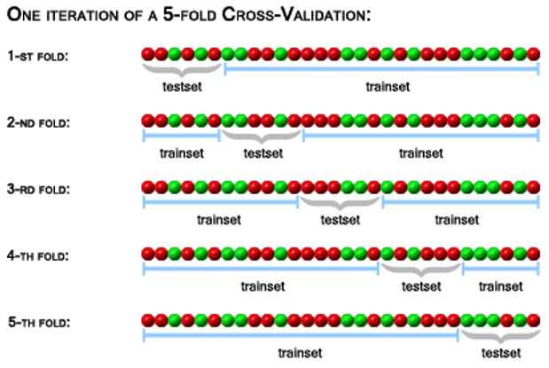

Cross-Validation

Here we use the 10-fold cross-validation for evaluating the regression model performance:

```r
car_rdesc_cv <- makeResampleDesc(method = "CV",
                                 iters = 10,
                                 stratify.cols = "car")
set.seed(123)

resample(learner = lrn_lm,
         resampling = car_rdesc_cv,
         task = car_imputed,
         measures = reg_ms,
         show.info = TRUE)
```

```
## Resampling: cross-validation
```

```
## Measures:             rmse      mape      mae
```

```
## [Resample] iter 1:    17079.27284121.2809368    8465.6065501
```

```
## [Resample] iter 2:    13822.69277511.2242975    8241.2851135
```

```
## [Resample] iter 3:    13323.90166831.0989018    7761.2847540
```

```
## [Resample] iter 4:    19388.94044681.0909328    8193.8495521
```

```
## [Resample] iter 5:    18502.77121511.0154162    8728.0074173
```

```
## [Resample] iter 6:    22042.68192011.0098892    8575.7435577
```

```
## [Resample] iter 7:    14452.30617141.1191783    8189.3914121
```

```
## [Resample] iter 8:    16911.11249721.1511344    8765.7585587
```

```
## [Resample] iter 9:    15026.09926521.1416800    8272.7588323
```

```
## [Resample] iter 10:   18099.73165371.0171624    7921.2041009
```

```
## Aggregated Result: rmse.test.rmse=17066.6251999,mape.test.mean=1.1149529,mae.test.mean=8311.4889849
```

```
## Resample Result
## Task: Car prices
## Learner: Linear Regression
## Aggr perf: rmse.test.rmse=17066.6251999,mape.test.mean=1.1149529,mae.test.mean=8311.4889849
## Runtime: 0.315157
```

### Step 6. Forecasting

The new model can be applied to the new data using the `predict()` function.

When the training data was preprocessed, the same preprocessing steps should be applied to new data as well. In our case we imputed the missing values, and stored the imputation stragegy in the `car_imputation` variable. Now we can re-apply the imputation strategy to the new data using the `reimpute()` function.

We must also ensure, that the factor levels in new data are the same, as in the training data

```r
# Creating a new car
new_car2 <- tibble(car = "Ford", body = "crossover",
              mileage = 10, engV = 2.7,
              inv_mileage = 1000 / (10 + 1),
              engType = "Gas", registration = "yes",
              year = 2012, drive = "full", model = ".other"
              )

# Applying the imputation strategy
new_car2_imp <- new_car2 %>%
  mutate_if(is.character, as.factor) %>%
  reimpute(desc = car_imputation$desc)

# In our case there's no difference, since there were no NAs in new data
predict(car_mod_lm, newdata = new_car2)
```

```
## Prediction: 1 observations
## predict.type: response
## threshold:
## time: 0.00
##   response
## 1 29712.16
```

```r
predict(car_mod_lm, newdata = new_car2_imp)
```

```
## Prediction: 1 observations
## predict.type: response
## threshold:
## time: 0.00
##   response
## 1 29712.16
```

### Plotting the forecasts

For asssessment of the model’s adequacy visual inspection of the forecasts is an important step. The mlr package has built-in visualization tools that are helpful for checking how the model is doing on a particular dataset. These tools are limited just to two predictors, since we can’t visualize more than 3 dimensions. Despite this, it can be useful to understand what’s going on.

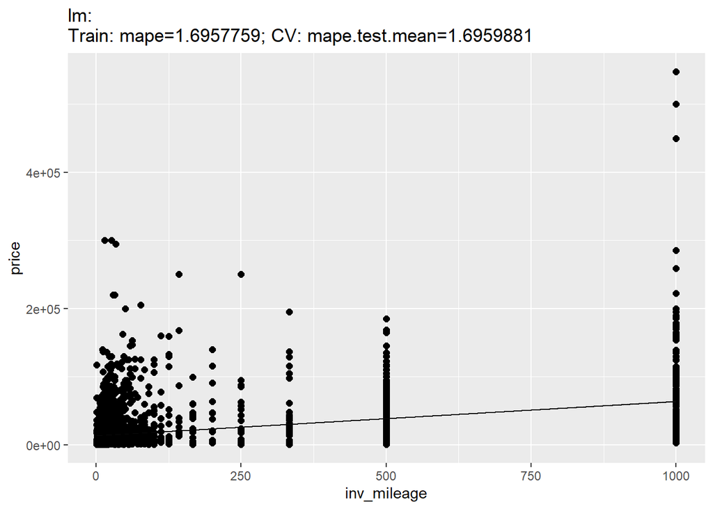

```r
plotLearnerPrediction(lrn_lm, task = car_imputed,
                      features = "inv_mileage",
                      measures = mape)
```

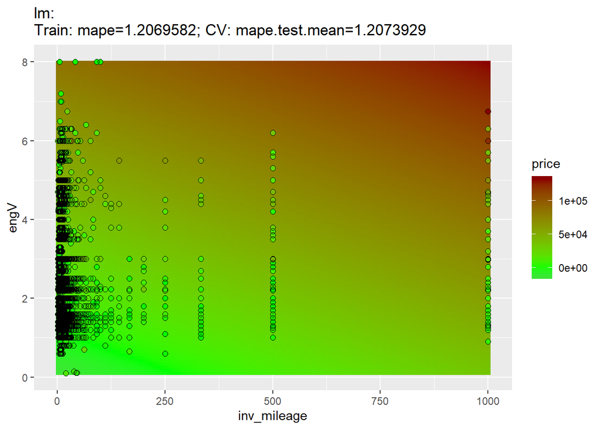

```r
plotLearnerPrediction(lrn_lm, task = car_imputed,
                      features = c("inv_mileage", "engV"),
                      measures = mape)
```

### Comparing the regression models

Let’s compare several regression models - linear regression (lm), lasso and ridge regression (glmnet), and two types of trees - rpart and ctree.

The `makeLearners()` function can create several learners at once. The resulting list of learners can be later extended by adding new models.

```r
car_learners <- makeLearners(
  c("lm", "glmnet", "rpart", "ctree"),
  ids = c("lm", "lasso", "rpart", "ctree"),
  type = "regr")
```

The default type of regression used by glmnet is lasso (`\alpha = 1`). Let’s create another learner for ridge regression and add it to the list.

```r
lrn_ridge <- makeLearner(cl = "regr.glmnet", id = "ridge", alpha = 0)
lrn_ridge %>% getLearnerParVals()
```

```
## $s
## [1] 0.01
##
## $alpha
## [1] 0
```

```r
car_learners$ridge <- lrn_ridge
```

One way of comparing the models is processing the resulting list of learners using the `lapply()` function. This function applies a given function fo each element of a list and stores the results in a new list.

```r
car_models <- car_learners %>%
  lapply(train, task = car_imputed)
```

We can plot the output of the models limited to two predictors - inverse mileage and engine volume:

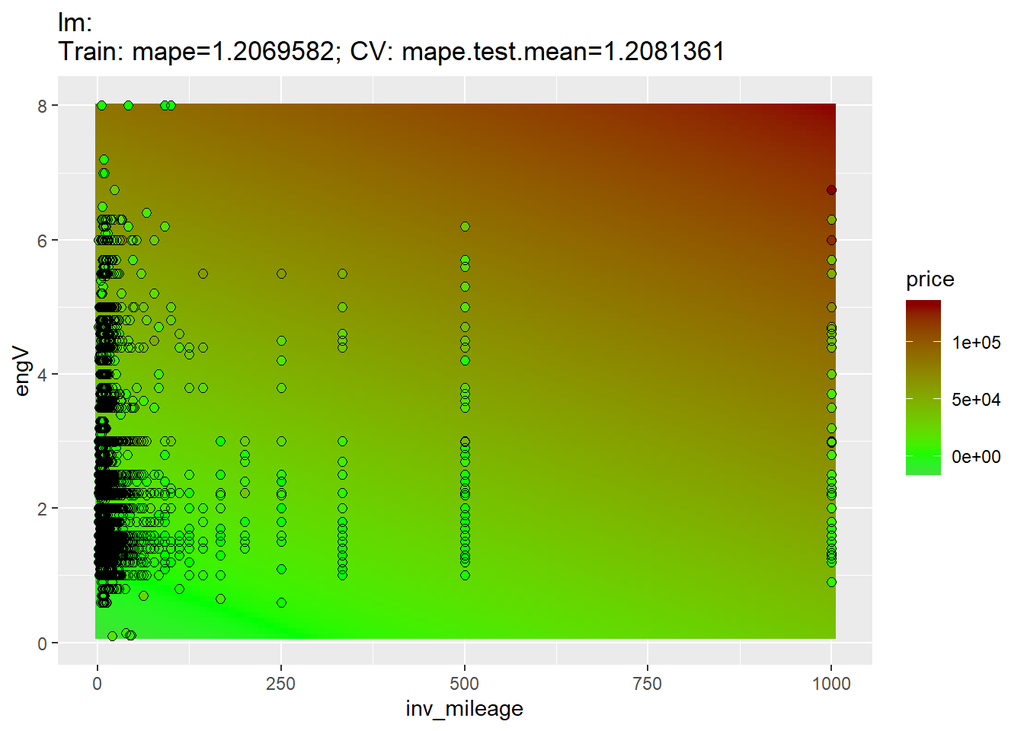

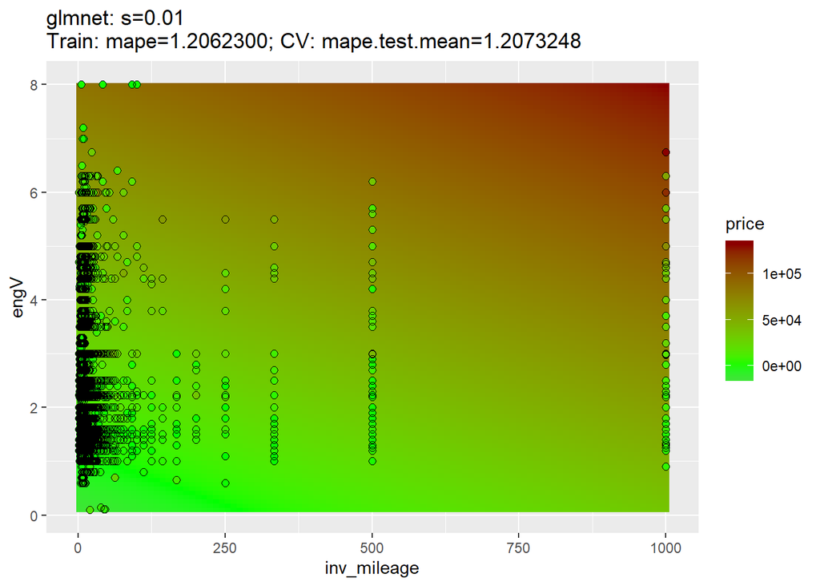

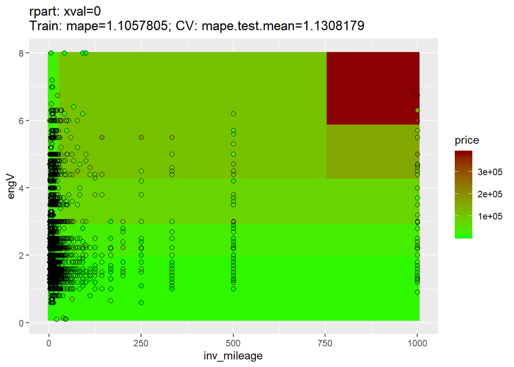

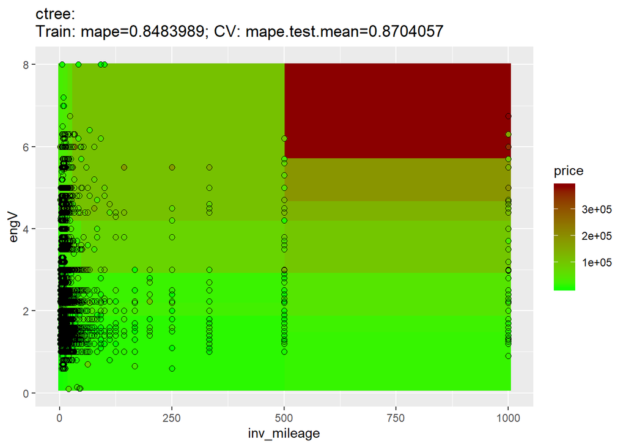

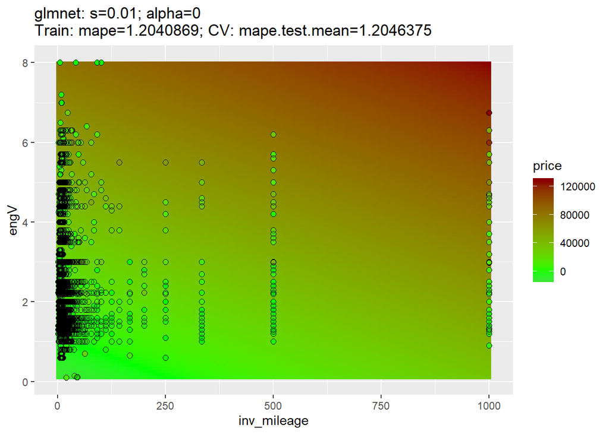

```r
car_learners %>%
  lapply(plotLearnerPrediction,
         task = car_imputed,
         features = c("inv_mileage", "engV"),
         measures = mape)
```

The best results are obtained from the ctree model.

The performance measures can be computed using the `resample()` function. We can apply it to the list of learners using the `lapply()` function:

```r
set.seed(123)
car_learners %>%
  lapply(resample, task = car_imputed,
         resampling = car_rdesc_cv,
         measures = reg_ms,
         show.info = FALSE)
```

[output not shown]

Thers’s a better way of comparing the models in mlr - by using the `benchmark()` function. This function can in one step apply multiple learners to multiple traning tasks and compare the performance using a selected resampling stragegy. This can be done using parallell computation, which can speed-up the process on modern multi-core CPUs.

```r
set.seed(123, "L'Ecuyer") # For reproducibility. The L'Ecuyer random number generator must be used, if parallel computation is used.

# Detecting the number of avaliable CPU cores
num_cores <- parallel::detectCores()

# Starting parallelization
parallelStartSocket(num_cores) # This method is used for Windows, but other methods are available for Unix-based systems.
```

```
## Starting parallelization in mode=socket with cpus=16.
```

```r
car_bench <- car_learners %>%
  benchmark(tasks = car_imputed,
         resampling = car_rdesc_cv,
         measures = append(list(timetrain), reg_ms),
         show.info = FALSE)
```

```
## Exporting objects to slaves for mode socket: .mlr.slave.options
```

```
## Mapping in parallel: mode = socket; level = mlr.benchmark; cpus = 16; elements = 5.
```

```r
# Stopping parallelization
parallelStop()
```

```
## Stopped parallelization. All cleaned up.
```

The results are assembled into a benchmarking results object, which is stored in the `car_bench` variable. The benchmarking results can be converted into a table and visualized:

```r
car_bench %>%
  getBMRAggrPerformances(as.df = TRUE) %>%
  arrange(mape.test.mean) %>%
  select(learner.id, mape.test.mean, timetrain.test.mean)
```

```
##   learner.id mape.test.mean timetrain.test.mean
## 1      ctree      0.2876680               0.325
## 2      rpart      0.7388461               0.006
## 3      ridge      1.0722773               0.030
## 4      lasso      1.1098405               0.025
## 5         lm      1.1141445               0.016
```

Plotting the benchmarking results:

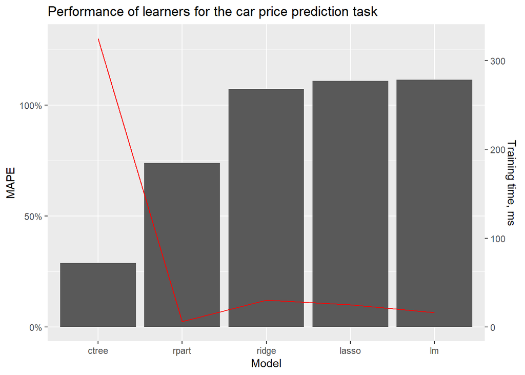

```r
car_bench %>%
  getBMRAggrPerformances(as.df = TRUE) %>%
  arrange(mape.test.mean) %>%
  ggplot(aes(x = fct_inorder(learner.id),
             y = mape.test.mean)) +
  geom_bar(stat = "identity") +
  geom_line(aes(y = timetrain.test.mean * 4, group = 1),
            color = "red") +
  scale_y_continuous(labels = scales::percent,
                     sec.axis = sec_axis(~ . * 1000 / 4,
                                         name = "Training time, ms")) +
  labs(title = "Performance of learners for the car price prediction task",
       x = "Model", y = "MAPE")
```

The most accurate algorithm is ctree, the fastest - rpart.

See laso https://mlr.mlr-org.com/articles/tutorial/benchmark_experiments.html

# Classification with mlr

## Loading data and exploratory analysis

Here we use the mlr package to train classifiers. We’ll consider the employee turnover classification problem considered in the tutorial on decision trees (../decision-trees/decision-trees.Rmd).

Loading data

```r
turnover <- readRDS("turnover.RDS")
head(turnover)
```

```
## # A tibble: 6 x 10
##   satisfaction_le~ last_evaluation number_project average_monthly~
##              <dbl>           <dbl>          <dbl>            <dbl>
## 1             6.9             5.90              4              266
## 2             6.8             5.4               4              146
## 3             5.90            5.8               2              267
## 4             7.3             6.1               4              260
## 5             4.9             4                 2              148
## 6             8.6             9.8               3              158
## # ... with 6 more variables: time_in_company <dbl>, work_accident <fct>,
## #   left <fct>, promotion_last_5years <fct>, department <fct>,
## #   salary <fct>
```

Plotting turnover vs monthly workload and evaluation score of an employee.

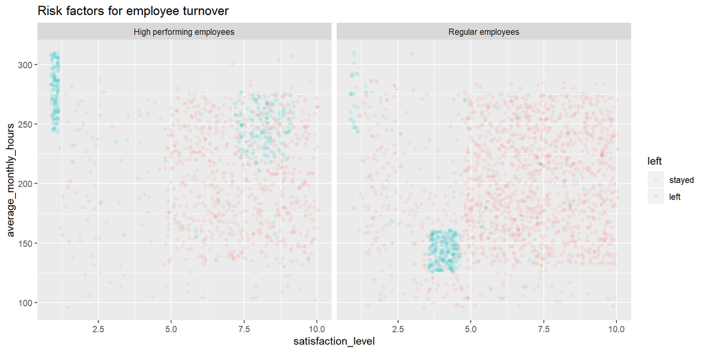

```r
turnover %>%
  mutate(performance = if_else(last_evaluation >= 8,
                               "High performing employees", "Regular employees")) %>%
  ggplot(aes(x = satisfaction_level,
             y = average_monthly_hours,
             color = left)) + #,
             #size = last_evaluation >= 8)) +
  geom_jitter(alpha = 0.1) +
  facet_wrap(~ performance) +
  labs(title = "Risk factors for employee turnover")
```

Checking variable distributions and assessing the technical data quality:

```r
summary(turnover)
```

```
##  satisfaction_level last_evaluation  number_project  average_monthly_hours
##  Min.   : 0.90      Min.   : 3.600   Min.   :2.000   Min.   : 96.0
##  1st Qu.: 4.50      1st Qu.: 5.600   1st Qu.:3.000   1st Qu.:158.0
##  Median : 6.50      Median : 7.300   Median :4.000   Median :202.0
##  Mean   : 6.17      Mean   : 7.191   Mean   :3.819   Mean   :202.3
##  3rd Qu.: 8.20      3rd Qu.: 8.700   3rd Qu.:5.000   3rd Qu.:246.0
##  Max.   :10.00      Max.   :10.000   Max.   :7.000   Max.   :310.0
##
##  time_in_company  work_accident     left      promotion_last_5years
##  Min.   : 2.000   no :2598      stayed:2301   no :2946
##  1st Qu.: 3.000   yes: 402      left  : 699   yes:  54
##  Median : 3.000
##  Mean   : 3.529
##  3rd Qu.: 4.000
##  Max.   :10.000
##
##        department     salary
##  sales      :790   low   :1474
##  technical  :552   medium:1255
##  support    :448   high  : 271
##  IT         :259
##  product_mng:180
##  accounting :172
##  (Other)    :599
```

No missing values are present

## Creating a learning task

```r
turnover_task <- makeClassifTask(id = "Employee turnover",
                                 data = turnover,
                                 target = "left",
                                 positive = "left")
turnover_task
```

```
## Supervised task: Employee turnover
## Type: classif
## Target: left
## Observations: 3000
## Features:
##    numerics     factors     ordered functionals
##           5           4           0           0
## Missings: FALSE
## Has weights: FALSE
## Has blocking: FALSE
## Has coordinates: FALSE
## Classes: 2
## stayed   left
##   2301    699
## Positive class: left
```

## Creating a learner

The number of available classification learners:

```r
listLearners("classif") %>%
  count()
```

```
## # A tibble: 1 x 1
##       n
##   <int>
## 1    82
```

A list of available classification learners:

```r
listLearners("classif") %>%
  select(name, package) %>%
  mutate(name = substr(name, 1, 60)) %>%
  head(10)
```

```
##                                                  name            package
## 1                                        ada Boosting          ada,rpart
## 2                                     ada Boosting M1              RWeka
## 3                  Bayesian Additive Regression Trees        bartMachine
## 4                                 Binomial Regression              stats
## 5                                     Adabag Boosting       adabag,rpart
## 6                                   Gradient Boosting          bst,rpart
## 7                                                 C50                C50
## 8  Random forest based on conditional inference trees              party
## 9                   Clustered Support Vector Machines SwarmSVM,LiblineaR
## 10                        Conditional Inference Trees              party
```

See also the online help for [Available Learners]https://mlr.mlr-org.com/articles/tutorial/integrated_learners.html

Here we create a list of classification learners:

```r
turnover_learners <-
  makeLearners(cls = c("logreg", "rpart", "ctree", "C50"),
               ids = c("Log. regression", "rpart", "ctree", "C5.0"),
               type = "classif", predict.type = "prob")
```

By adding the `type` parameter, we can shorten class names by omitting the `classif.` prefix for the algorithm name from the table.

## Benchmarking the classifiers

Let’s create the resampling strategy for our classification taks:

```r
turnover_rdesc <- makeResampleDesc(method = "CV",
                                   stratify = TRUE,
                                   iter = 10)
```

Here we also use stratification, but instead of splitting by predictor values, here we try to maintain the same proportion of class labels in training and test samples. This means, that the proportion of employees who are leaving the company will be the same in training and testing samples.

Let’s compare the models using the `benchmark()` function:

```r
# A list of model performance metrics for classification
clas_ms = list(auc, kappa, mmce, tpr, tnr, fpr)

# Setting the random number generator for reproducibility
set.seed(123, "L'Ecuyer")

# Starting parallelization
parallelStartSocket(num_cores)
```

```
## Starting parallelization in mode=socket with cpus=16.
```

```r
turnover_bench <- turnover_learners %>%
  benchmark(tasks = turnover_task,
         resampling = turnover_rdesc,
         measures = append(list(timetrain), clas_ms),
         show.info = FALSE)
```

```
## Exporting objects to slaves for mode socket: .mlr.slave.options
```

```
## Mapping in parallel: mode = socket; level = mlr.benchmark; cpus = 16; elements = 4.
```

```r
parallelStop()
```

```
## Stopped parallelization. All cleaned up.
```

Extracting and analysing the benchmarking results

```r
turnover_bench %>%
  getBMRAggrPerformances(as.df = TRUE) %>%
  arrange(desc(auc.test.mean)) %>%
  select(-task.id) %>%
  mutate_if(is.numeric, round, digits = 3)
```

```
##        learner.id timetrain.test.mean auc.test.mean kappa.test.mean
## 1            C5.0               0.052         0.965           0.916
## 2           rpart               0.004         0.963           0.904
## 3           ctree               0.025         0.952           0.801
## 4 Log. regression               0.015         0.821           0.272
##   mmce.test.mean tpr.test.mean tnr.test.mean fpr.test.mean
## 1          0.029         0.910         0.989         0.011
## 2          0.034         0.907         0.984         0.016
## 3          0.073         0.888         0.938         0.062
## 4          0.218         0.300         0.928         0.072
```

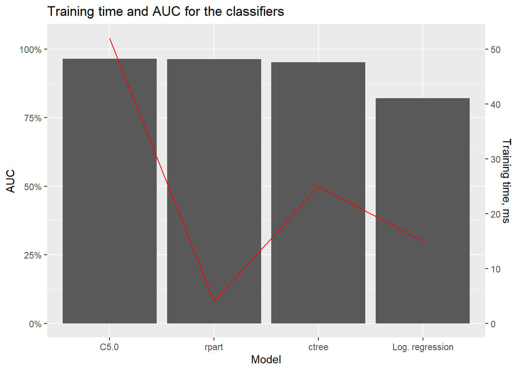

```r
turnover_bench %>%
  getBMRAggrPerformances(as.df = TRUE) %>%
  arrange(desc(auc.test.mean)) %>%
  ggplot(aes(x = fct_inorder(learner.id))) +
           geom_bar(aes(y = auc.test.mean), stat = "identity") +
           geom_line(aes(y = timetrain.test.mean * 20, group = 1),
                     colour = "red") +
  scale_y_continuous(sec.axis = sec_axis(~ . * 1000 / 20,
                                         name = "Training time, ms"),
                     labels = scales::percent) +
    labs(title = "Training time and AUC for the classifiers",
       x = "Model", y = "AUC")
```

The most accurate algorithm is C5.0, the fastest - rpart. This algorithm is also very close in terms of accuracy to the leader.

Let’s plot the decision boundaries for the classifers. We can use at most two predictors - the satisfaction level and the monthly workload:

```
## $`Log. regression`
```

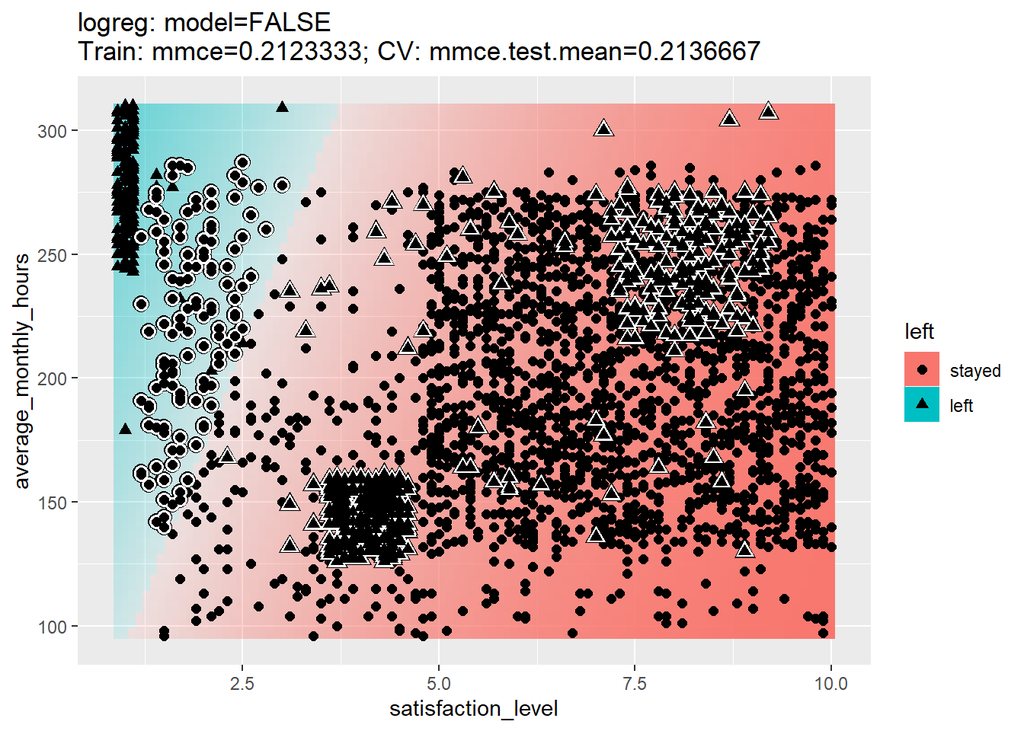

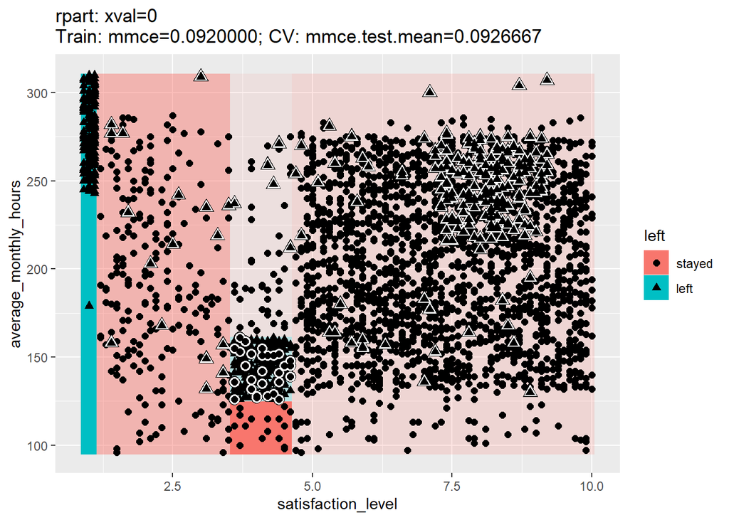

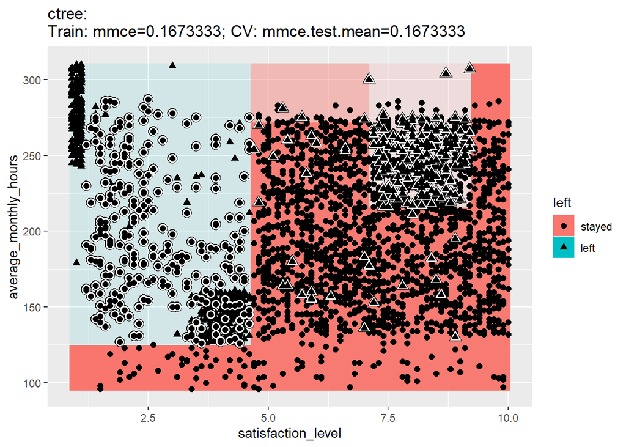

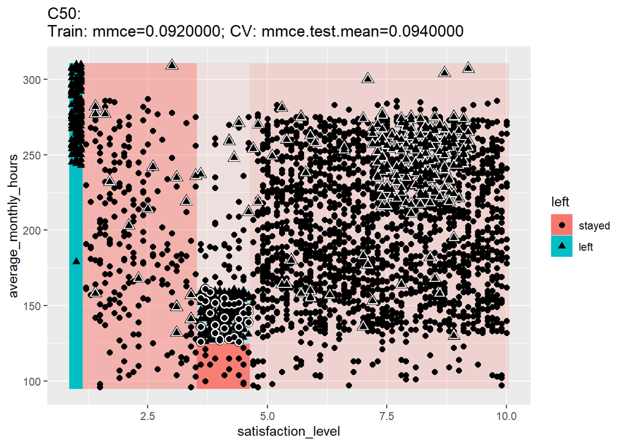

```r
turnover_learners %>%
  lapply(plotLearnerPrediction, task = turnover_task,
         features = c("satisfaction_level",
                      "average_monthly_hours"))
```

## Exploring the classifiers

Let’s extract a trained rpart model that has demonstrated the best balance for speed and accuracy:

```r
turnover_rpart <- turnover_learners$rpart
turnover_rpart
```

```
## Learner rpart from package rpart
## Type: classif
## Name: Decision Tree; Short name: rpart
## Class: classif.rpart
## Properties: twoclass,multiclass,missings,numerics,factors,ordered,prob,weights,featimp
## Predict-Type: prob
## Hyperparameters: xval=0
```

For plotting ROCs, we need to create a forecast for test data. For this, we’ll split the `turnover_task` learning task into a training and a testing subtasks.

```r
set.seed(123)
# Task size - the number of examples
turnover_n <- getTaskSize(turnover_task)

# sampling the row indices for training and testing subsamples
turnover_train <- sample(turnover_n, size = 0.7 * turnover_n)
turnover_test <- setdiff(1:turnover_n, turnover_train)
```

Training the model and forecasting on the test sample:

```r
turnover_m_rpart <- train(learner = turnover_rpart,
                          task = turnover_task,
                          subset = turnover_train)

turnover_pr_rpart <- predict(turnover_m_rpart,
                             task = turnover_task,
                             subset = turnover_test)
```

Plotting the resulting decision tree:

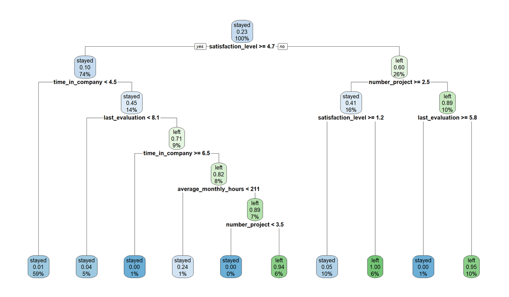

```r
rpart.plot(getLearnerModel(turnover_m_rpart), cex = 0.8, roundint = F)
```

Classifier performance on the test sample:

```r
performance(turnover_pr_rpart,
            measures = clas_ms) %>%
  round(4)
```

```
##    auc  kappa   mmce    tpr    tnr    fpr
## 0.9442 0.8931 0.0378 0.8750 0.9898 0.0102
```

Depending on the threshold, the sensitivity (TPR) and the FPR of the classifier will change.

The current threshold is 50%:

```r
turnover_pr_rpart$threshold
```

```
## stayed   left
##    0.5    0.5
```

When required, the classifier threshold can be set using the `setThreshold()` function.

For building the ROC, we need to generate the table for TPR and FPR corresponding to different thresholds. This is done using the `generateThreshVsPerfData()`. The first metrics for the list sholuld be FPR and TPR, since these are used for plotting the ROC.

Afterwards, we can plot the individual performance metrics using the `plotThreshVsPerf()` function:

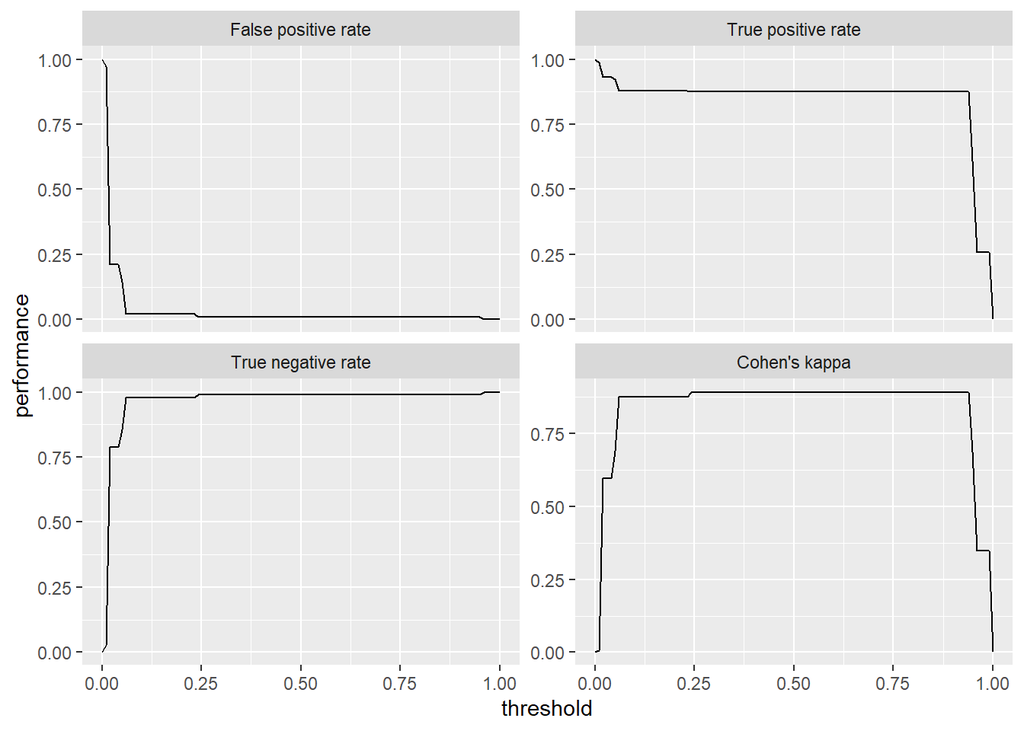

```r
turnover_roc <- generateThreshVsPerfData(turnover_pr_rpart,
                         measures = list(fpr, tpr, tnr, kappa))
plotThreshVsPerf(turnover_roc)
```

The same data are used for the ROC plot:

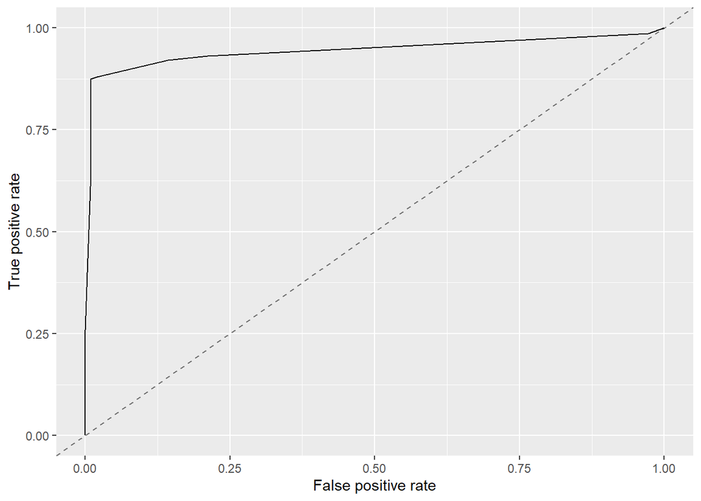

```r
plotROCCurves(turnover_roc)
```

The confusion matrix is computed using the `calculateConfusionMatrix()` function:

```r
calculateConfusionMatrix(turnover_pr_rpart)
```

```
##         predicted
## true     stayed left -err.-
##   stayed    677    7      7
##   left       27  189     27
##   -err.-     27    7     34
```

When required, the proportions of different error types can be calculated instead of counts:

```r
calculateConfusionMatrix(turnover_pr_rpart, relative = T)
```

```
## Relative confusion matrix (normalized by row/column):
##         predicted
## true     stayed    left      -err.-
##   stayed 0.99/0.96 0.01/0.04 0.01
##   left   0.12/0.04 0.88/0.96 0.12
##   -err.-      0.04      0.04 0.04
##
##
## Absolute confusion matrix:
##         predicted
## true     stayed left -err.-
##   stayed    677    7      7
##   left       27  189     27
##   -err.-     27    7     34
```

To compare several models, we can use the `lapply()` function for list processing:

```r
turnover_models <-
  turnover_learners %>%
  lapply(train, task = turnover_task, subset = turnover_train)

turnover_predictions <-
  turnover_models %>%
  lapply(predict, task = turnover_task, subset = turnover_test)
```

The ROC plotting function can handle lists on its own:

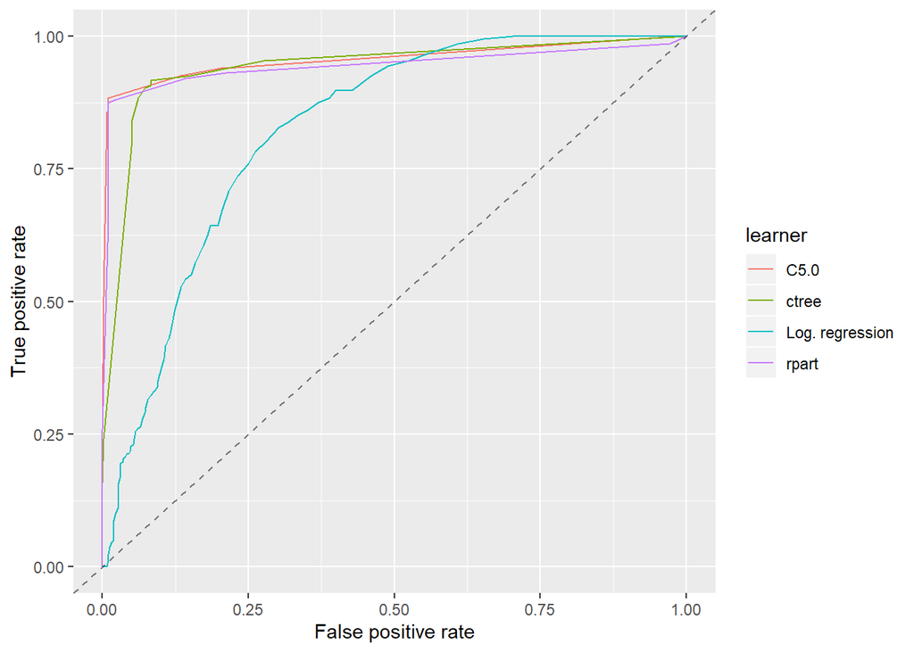

```r
turnover_roc2 <-
  generateThreshVsPerfData(turnover_predictions,
                           measures = list(fpr, tpr))

plotROCCurves(turnover_roc2)
```

We can also extract the data table stored inside the object generated by `generateThreshVsPerfData()` and use regular `ggplot2` syntax to create a custom visualization:

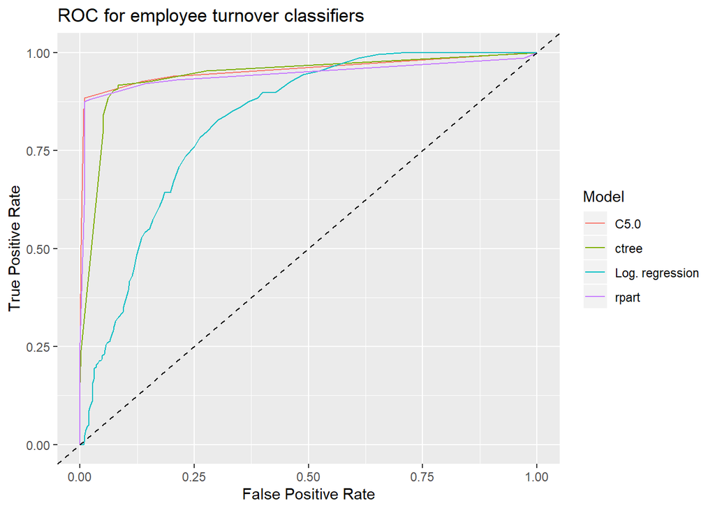

```r
turnover_roc2$data %>%
  ggplot(aes(fpr, tpr, colour = learner)) +
  geom_path() +
  geom_abline(slope = 1, linetype = "dashed") +
  labs(title = "ROC for employee turnover classifiers",
       colour = "Model",
       x = "False Positive Rate",
       y = "True Positive Rate")
```

The best results are obtained from C5.0 and rpart models.

See also https://mlr.mlr-org.com/articles/tutorial/roc_analysis.html

## Tuning the hyperparameters

Most machine learning algorithms have **hyperparameters** that control the behaviour of the algorithm and influence the performance of the resulting model. For example, the rpart decision tree algorithm has the following hyperparameters:

```r
getLearnerParamSet(turnover_rpart)
```

```
##                    Type len  Def   Constr Req Tunable Trafo
## minsplit        integer   -   20 1 to Inf   -    TRUE     -
## minbucket       integer   -    - 1 to Inf   -    TRUE     -
## cp              numeric   - 0.01   0 to 1   -    TRUE     -
## maxcompete      integer   -    4 0 to Inf   -    TRUE     -
## maxsurrogate    integer   -    5 0 to Inf   -    TRUE     -
## usesurrogate   discrete   -    2    0,1,2   -    TRUE     -
## surrogatestyle discrete   -    0      0,1   -    TRUE     -
## maxdepth        integer   -   30  1 to 30   -    TRUE     -
## xval            integer   -   10 0 to Inf   -   FALSE     -
## parms           untyped   -    -        -   -    TRUE     -
```

Consider two hyperparameters of a rpart tree: - `minsplit` - the minimum number of observations in a node for splitting,  
- `cp` - the complexity parameter - the minimum relative increase in the purity to keep a split.

Lower values of the parameters produce larger trees.

The table shown above lists the type, the default valuea, the range and the ability of tuning for each available hyperparameter.

To tune the hyperparameters, we create a parameter set using the `makeParamSet()` function. The list of parameters to tune and the range of values to consider should be provided as an input to the function.

```r
ps_rpart = makeParamSet(
  makeNumericParam("cp", lower = -4, upper = -2,
                   trafo = function(x) 10^x), # transformation function enables non-linear change
  makeIntegerParam("minsplit", lower = 4, upper = 30))
```

The `trafo` parameter allows to set a transformation function, that is applied to the range of values to enable the non-linear change in parameter values. Here we use the $10^x$ to create the set of values: {0.0001, 0.001, 0.01} for `cp`.

As the number of parameters in a set, or the range of each parameter grows, the number of possible combinations is exponentially increasing.

The mlr package provides several algorithms to optimize the hyperparameters - see https://mlr.mlr-org.com/articles/tutorial/tune.html.

The simplest, the most reliable and the slowest approach is the total enumeration of all possible parameter combinations. It is selected by the `makeTuneControlGrid()` function.

A quicker method is provided by `makeTuneControlRandom()` function. This method implements a random search, which can be quicker for larger search spaces, but it doesn’t provide any warranty for optimality.

Here we use the simulated annealing algorithm, that combines a directed search and random search. This method is provided by the `makeTuneControlGenSA()` function.

```r
# Setting the random number generator for reproducibility
set.seed(123, "L'Ecuyer")

# Selecting the optimization algorithm
control_rpart = makeTuneControlGenSA(budget = 200)

# Selecting the resampling strategy
cv_rdesc = makeResampleDesc("CV", iters = 5) # 10-fold CV would be slower

# Tuning the parameters
parallelStartSocket(num_cores)

res_rpart = tuneParams(turnover_rpart,
                       measures = auc,
                       task = turnover_task,
                       control = control_rpart,
                       resampling = cv_rdesc,
                       par.set = ps_rpart,
                       show.info = FALSE)

parallelStop()
```

The best combination of parameters:

```r
print(res_rpart)
```

```
## Tune result:
## Op. pars: cp=0.00114; minsplit=10
## auc.test.mean=0.9677746
```

We can visualize the relationship between the metric and the hyperparameter values:

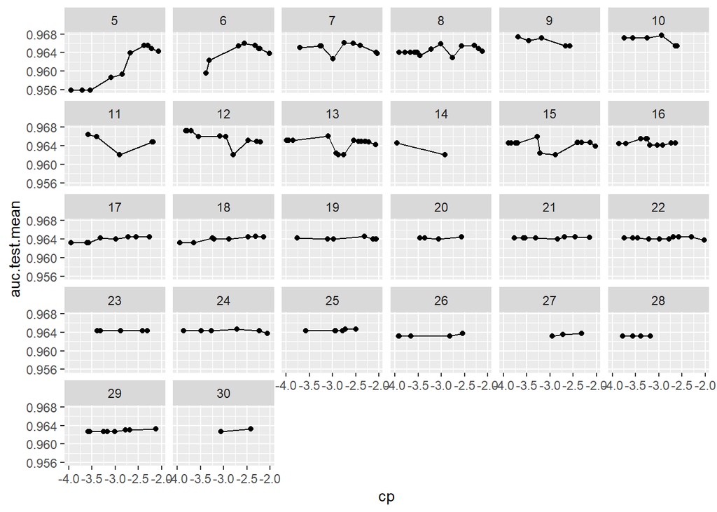

```r
generateHyperParsEffectData(res_rpart) %>%
  plotHyperParsEffect(x = "cp", y = "auc.test.mean",
                      plot.type = "line",
                      #z = "minsplit",
                      facet = "minsplit")
```

We can observe from the plots, that for higher `minsplit` values the AUC doesn’t depend much on the `cp`. But when `minsplit` is small, the `cp` becomes more important to prevent overfitting.

We can also plot a heatmap to show the dependence of AUC on two hyperparameters simultaneously:

[output not shown]

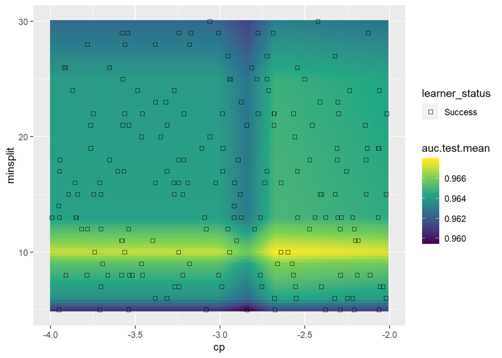

```r
generateHyperParsEffectData(res_rpart) %>%
  plotHyperParsEffect(x = "cp", y = "minsplit",
                      z = "auc.test.mean",
                      plot.type = "heatmap",
                      interpolate = "regr.earth",
                      show.experiments = TRUE) +
  scale_fill_viridis_c()
```

The heatmap shows the points obtained for different hyperparameter combinations while searching, as well as the interpolated surface for the AUC. Here we can see that the highest AUC is obtained for $minsplit \approx 10$ and $cp \approx 10^{-2.7}$

See also https://mlr.mlr-org.com/articles/tutorial/hyperpar_tuning_effects.html

Let’s create a model with optimized hyperparameters:

```r
# Creating a learner
turnover_rpart_opt <-  makeLearner("classif.rpart",
                                   predict.type = "prob",
                                   par.vals =
                                     list(cp = 10^(-2.7),
                                          minsplit = 10))
# Training the model
m_rpart_opt <- train(turnover_rpart_opt,
                     task = turnover_task,
                     subset = turnover_train)

# Forecasting on the test sample
pr_rpart_opt <- predict(m_rpart_opt, task = turnover_task,
                        subset = turnover_test)
```

Let’s compare the optimized and the initial model

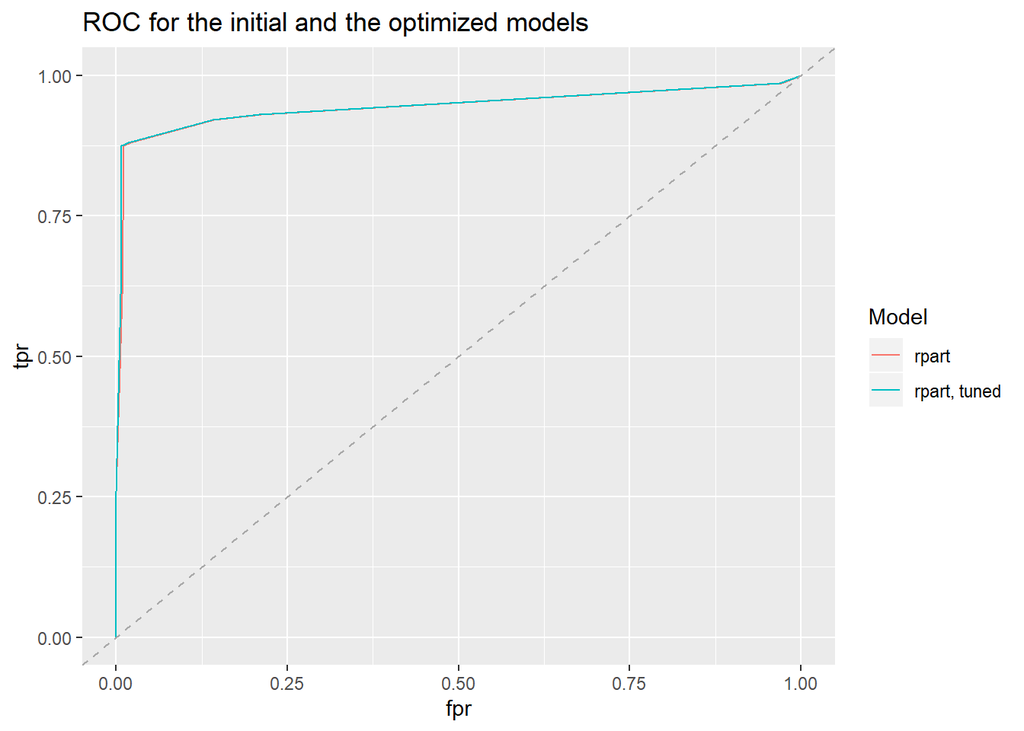

```r
# Getting data for ROCs
turnover_rpart_compare <-
  generateThreshVsPerfData(
    list("rpart" = turnover_predictions$rpart,
         "rpart, tuned" = pr_rpart_opt),
    measures = list(fpr, tpr))

# Comparing the ROCs
turnover_rpart_compare$data %>%
  ggplot(aes(x = fpr, y = tpr, color = learner)) +
  geom_path() +
  geom_abline(slope = 1, linetype = "dashed",
              color = "darkgray") +
  labs(title = "ROC for the initial and the optimized models",
       colour = "Model")
```

A tiny improvement…

Let’s compare also the trees constructed by the two models

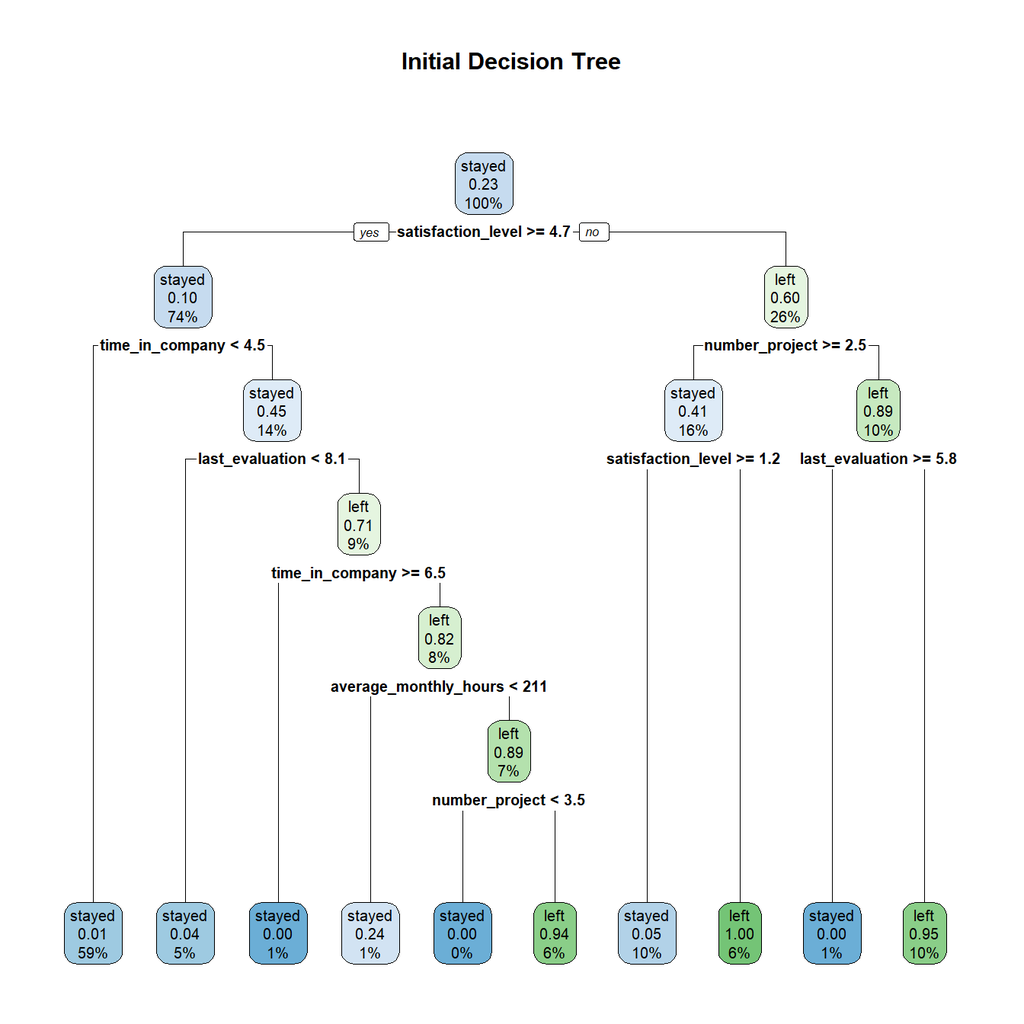

```r
# Initial model
getLearnerModel(turnover_m_rpart) %>%
  rpart.plot(main = "Initial Decision Tree", roundint=F)
```

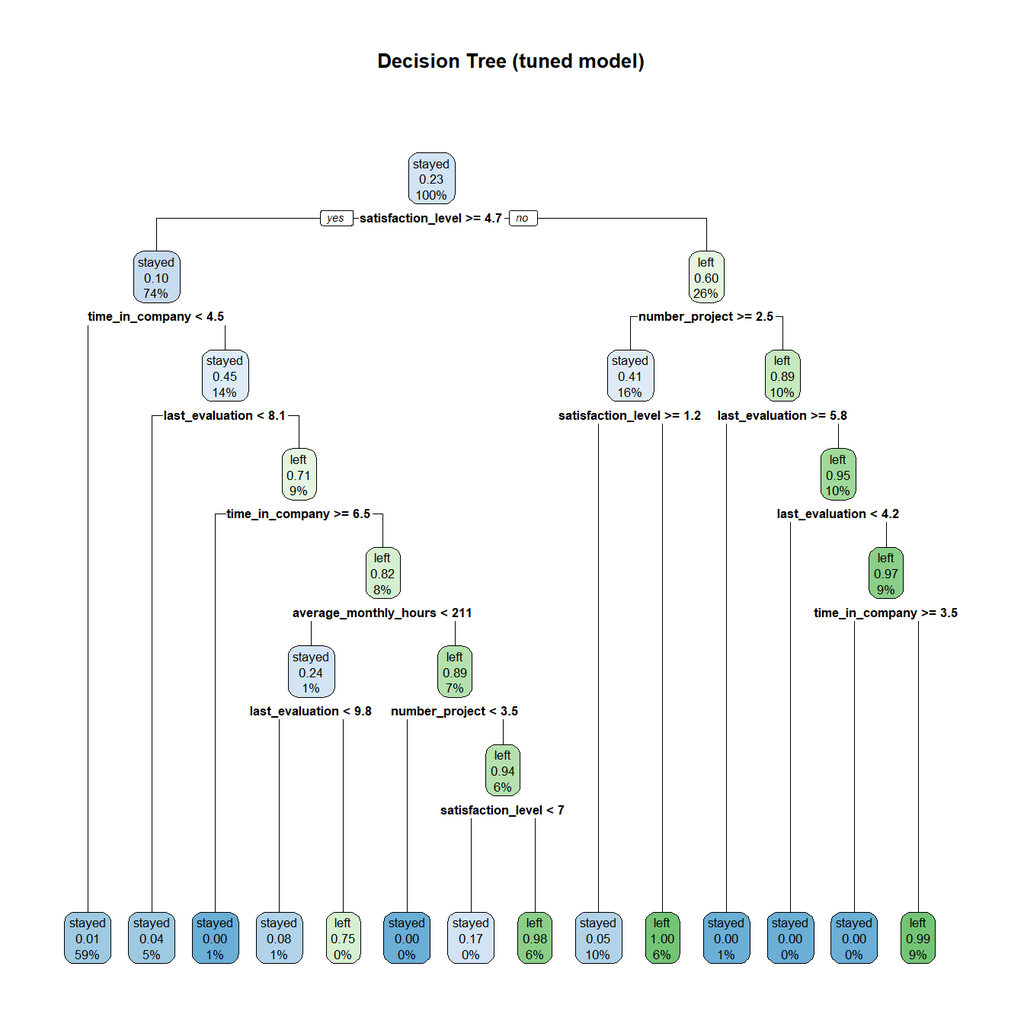

```r
# Tuned model
getLearnerModel(model = m_rpart_opt) %>%
  rpart.plot(main = "Decision Tree (tuned model)", roundint=F)
```

The tuned model allowed a slightly larger decision tree.